> 13 Sep 2017 » statistics

수식이 깨질 경우 새로고침을 눌러주세요.

# 가설과 검정 ②

## 검정 방법

> 검정을 어떻게 할 것인가?

> 분포의 파라미터 값이 특정한 값임을 어떻게 보일 것인가?

> 검정 통계량(Test Statistics)

### 일반적인 검정 방법은 다음과 같다.

> 1. 모수 값이 특정한 조건을 만족한다면 해당 확률 변수로부터 만들어진 표본(sample) 데이터들은 어떤 규칙을 따르게 된다.
> 2. 표본(데이터 집합)에서 어떤 규칙에 따라 값을 구하면 그 값은 특정한 확률 분포를 따르게 된다. 이 값을 **검정 통계량(test statistics)**라고 한다.
> 3. 검정통계량이 따르는 확률 분포를 **검정 통계 분포(test statistics distribution)**라고 한다.
> 4. 검정 통계 분포의 종류 및 모수의 값은 처음에 정한 가설(귀무 가설)에 의해 결정된다.
> 5. 만약 유의 확률이 미리 정한 특정한 기준값보다 작은 경우를 생각하자.
>    - 이 기준값을 **유의 수준(significance level)**이라고 하는 데 보통 1% 혹은 5% 정도의 작은 값을 지정한다.
>    - 유의 확률이 유의 수준보다도 작다는 말은 해당 검정 통계 분포에서 이 검정 통계치가 나올 수 있는 확률이 아주 작다는 의미이다.
>    - 즉, 귀무 가설이 틀렸다는 의미이다. 따라서 이 경우, 귀무 가설을 **기각(reject)**한다.
> 6. 만약 유의 확률이 유의 수준보다 크다면
>    - 검정 통계 분포에서 이 검정 통계량이 나오는 것이 불가능하지만은 않다는 의미이므로 귀무 가설을 기각할 수 없다.
>    - 따라서, 이 경우에는 귀무 가설을 **채택(accept)**한다.

### 검정 통계량

> 원래의 확률 변수와 관련이 있는 새로운 확률 변수

> 가설 검정에서 증명하고자 하는 **원래 확률 변수의 확률 분모 파라미터(theta)의 값에 의해 검정 통계량 분포의 파라미터(alpha)가 결정**된다.

$$\bbox[7px, border:2px solid blue]{ \theta → \alpha} $$

> 그렇다면, 검정 통계량은 무엇일까?
> - 검정을 하려면 즉, 귀무 가설이 맞거나 틀린 것을 증명하려면 어떤 증거가 있어야 한다. 이 증거가 검정 통계량(test statistics)이다.

> 예를 들어 이해해보자.
> 1. 환자가 "어떤 병에 걸렸다"라는 가설을 증명하려면 환자의 혈액을 채취하여 혈액 내 특정한 성분의 수치를 측정해야 한다.
>    - 이 때 혈액 내 특정한 성분의 수치가 검정 통계량이 된다.
> 2. "어떤 학생이 우등상을 받을 것이다."라는 가설을 증명하려면 시험 성적을 알아내면 된다.
>    - 이 때, 시험 성적이 검정 통계량이다.

> **수식**
> - 검정 통계량은 아래처럼 확률변수에 관한 수식으로 표현할 수 있다.

$$ \text{Test Statistics(검정 통계량) } $$$$ T = f(x_1, x_2, \ldots, x_n) $$

### 검정 통계량의 예

> **sum(합)**
> - 동전을 던져서 앞면이 나온 횟수(Bernoulli 분포의 sample의 합)
> - 정규 분포의 sample의 합

>   > 수익률 ~ N(평균, 분산) $$ N\text{개의 수익률 데이터}\;\; x_1, \cdots, x_N \text{에서 다음 수식으로 계산한 값도 검정 통계량이 된다.} $$

$$ \bbox[8px, border:2px solid red]{검정통계량\; T = \dfrac{m}{s/\sqrt{N}}} \\ \\단,\;\; m = \dfrac{1}{N}\sum_{i=1}^{N} x_i,\;\;\;\; s^2 = \dfrac{1}{N}\sum_{i=1}^{N} (x_i-m)^2\; 이다. $$

> **sum of squared(제곱의 합)**
> - 분산 및 표준편차 검정에 사용

> **ratio of sums(두 sample 집합의 합의 비율)**
> - 두 랜덤 변수의 파라미터 비교에 사용

#### 검정 통계량에 대해 좀 더 이해해보자.

> 검정 통계량은 표본 자료에서 계산된 함수값이므로 표본처럼 확률적(random)이다.

> 즉, 경우에 따라 표본 값이 달라질 수 있는 것처럼 달라진 표본값에 의해 검정 통계량도 달라진다.

$$\text{따라서 검정 통계량}\;\; t\; \text{도 검정 통계량 확률 변수}\;\; T\;\text{라는 확률 변수의 표본으로 볼 수 있다.}$$

> 또한, 어떤 귀무 가설을 만족하는 표본을 입력 변수로 놓고 특정한 함수로 계산한 검정 통계량이 특정한 분포를 따른다는 것을 수학적인 증명을 통해 보여야 한다.

> 통계학자들의 중요한 업적 중의 하나가 특정한 귀무 가설에 대해 어떤 검정 통계량 함수가 어떤 검정 통계량 분포를 따른 다는 것을 증명한 것이다.

#### 다음 도식을 보고 기억해 두자.

[figure not shown]

## 일반적으로 많이 사용되는 검정 통계량에 대해 알아 보자.

### 1. 베르누이 분포 확률 변수

> 모수 theta를 가지는 베르누이 분포 확률 변수에 대해서는 전체 시도 횟수 N 번 중 성공한 횟수 n 자체를 검정 통계량으로 쓸 수 있다.

> 이 검정 통계량은 자유도 (N) 과 모수 theta를 가지는 이항 분포를 따른다.

$$ x \sim Bern(\theta) \;\; \rightarrow \;\; t = \sum x \sim Bin(N, \theta) $$

### 2. 카테고리 분포 확률 변수

> 모수 벡터 alpha를 가지는 카테고리 분포 확률 변수에 대해서는 전체 시도 횟수 N 번 중 성공한 횟수 벡터 X 자체를 검정 통계량으로 쓸 수 있다.

> 이 검정 통계량은 자유도 N과 모수 벡터 alpha를 가지는 다항 분포를 따른다.

$$ X \sim Cat(X;\boldsymbol\alpha) \;\; \rightarrow \;\; t = \sum x \sim Mul(X; N, \boldsymbol\alpha) $$

### 3. 모수의 분산을 알고 있는 정규 분포 확률 변수

> 모수의 분산을 알고 있는 정규 분포 확률 변수에 대해서는 다음과 같이 샘플 평균을 정규화(nomarlize)한 값을 검정 통계량으로 쓴다.

> 이 검정 통계량은 표준 정규 분포를 따른다. 이 검정 통계량은 특별히 z라고 부른다.

$$ x \sim \mathcal{N}(\mu, \sigma^2) \;\; \rightarrow \;\; z = \dfrac{\bar{x}-\mu}{\sigma \;/\sqrt{N}} \sim \mathcal{N}(0,1) $$$$ \text{여기에서 }\;\;\;\bar{x} = \dfrac{1}{N}\sum_{i=1}^{N} x_i $$

### 4. 모수의 분산을 모르는 정규 분포 확률 변수

> **평균** 모수에 대한 검정을 할 때는 다음과 같이 샘플 평균을 샘플 분산으로 정규화(nomarlize)한 값을 검정 통계량으로 쓴다.

> 이 검정 통계량은 자유도가 (N-1)인 표준 student-t 분포를 따른다. (N) 은 데이터의 개수이다.

$$ x \sim \mathcal{N}(\mu, \sigma^2) \;\; \rightarrow \;\; t = \dfrac{\bar{x}-\mu}{s\;/\sqrt{N}} \sim t\;(0,1,N-1) $$$$ \text{단,} \;\; \bar{x} = \dfrac{1}{N}\sum_{i=1}^{N} x_i,\;\;\; s^2 = \dfrac{1}{N-1}\sum_{i=1}^{N} (x_i-m)^2 \\ \text(표본의 \;\;평균과\;\; 표본의\;\; 분산이다.) $$

> **분산** 모수에 대한 검정을 할 때는 다음과 같이 샘플 분산을 정규화(normalize)한 값을 검정 통계량으로 쓴다.

> 이 검정 통계량은 자유도가 N-1 인 카이 제곱 분포를 따른다. N 은 데이터의 개수이다.

$$ x \sim \mathcal{N}(\mu, \sigma^2) \;\; \rightarrow \;\; t = (N-1)\dfrac{s^2}{\sigma^2} \sim \chi^2 (t;N-1) $$

### 5. 기타 검정 통계량 확률 모형

> chi-squared
> - 정규 분포의 샘플 집합의 제곱의 합은 chi-squared 분포 $$ x \sim N \;\; \rightarrow \;\; \sum x^2 \sim \chi^2(N) $$

> F
> - 두 chi-squared 분포의 샘플의 (정규화된) 비율은 F 분포 $$ x_1, x_2 \sim \chi^2 \;\; \rightarrow \;\; \dfrac{x_1/s_1}{x_2/s_2} \sim F(n_1,\; n_2) $$
> - student-t 분포의 샘플의 제곱은 F 분포 $$ x \sim t \;\; \rightarrow \;\; x^2 \sim F $$

#### 위 내용을 도식 및 그림으로 정리하면 다음과 같다.

[figure not shown]

## 유의 확률 p-value

> 귀무 가설이 사실이라는 가정하에 검정 통계량이 따르는 검정 통계량 분포를 알고 있다면

> 실제 데이터에서 계산한 검정 통계량 숫자가 분포에서 어느 부분쯤에 위치해 있는지를 알 수 있다.

> 이 위치를 나타내는 값이 바로 **유의 확률(p-value)** 이다.

### 검정 통계량의 유의 확률(p-value)

> **검정 통계량 숫자보다 더 희귀한(rare) 값이면서 대립 가설을 따르는 값이 나올 수 있는 확률**을 말한다.

> 이 확률은 검정 통계 확률 분포 밀도 함수(pdf)에서 양 끝의 꼬리(tail)부분에 해당하는 영역의 면적으로 계산한다.

> 실제로는 누적 확률 분포 함수를 사용한다.

### P-value는 항상 헷갈린다! 뜬 구름 잡는 소리하지 말고 다음을 보고 이해하고 기억하자!

[figure not shown]

#### 위 분포는 귀무가설이 참이라고 가정하고, 그 가설을 바탕으로 그린 이론적 분포이다.

> **기억하자. p-value는 귀무 가설을 지지하는 확률**이다.

> 이 때, 주어진 자료를 바탕으로 m_1이라는 평균(검정 통계량)을 구했다.
> - m_1의 p-value가 크다 → 귀무가설을 기각할 수 없으므로, 일단은 채택(맞는지는 불확실하나 대안이 없으므로 채택)

> 또한, 주어진 자료를 바탕으로 m_2라는 평균(검정 통계량)을 구했다.
> - m_2의 p-value가 매우 작다. → **저 이론적 분포를 가져온 가설(귀무 가설)이 잘못되었다고 판단** → 귀무가설 기각 / **대립가설 채택**

### 위의 예로 P-value(유의 확률)의 개념을 잡았을 것이다.

### P-value의 개념을 간단히 다시 정리해보자.

- p-value는 귀무가설(null hypothesis, H0) 이 맞다는 전제 하에, 검정 통계량(statistics)이 실제로 관측된 값 이상일 확률이다.

  > 검정 통계량(statistics)이란 분포로부터 계산되는 값을 말하는데, 흔히 평균 / 평균의 차이 / 분산 / nth moment 등이 있을 수 있다.
- p-value는 귀무가설을 지지하는 확률
- p-value가 작으면 귀무가설이 틀렸다고 여기고, 기각하고 대립가설을 채택함.
- p-value는 현재 구한 통계값이 얼마나 자주 나올 것인가를 의미하기도 한다.
  - 가설검정은 전체 데이터를 갖고 하는 것이 아닌 sampling 된 데이터를 갖고 하는 것이다. 그래서 p-value가 필요함

### 머리가 아프겠지만 P-value(유의 확률)에 대한 오해를 바로 잡고 좀 더 깊이 이해해보자.

#### p-value는 귀무가설이 참일 확률이 아니다.

> p-value는 귀무가설을 지지하는 확률이다. (귀무 가설 하에 표본의 분포를 그리고 그 분포와 모분포(실제 이상적인 분포)를 비교할 수 있는 확률이다.)

> 귀무가설이 참일 확률은 구할 수 없다.

> p-value가 낮아도 귀무가설이 참일 수 있고, p-value가 (아주) 높아도 귀무가설은 틀릴 수 있다.

#### p-value와 유의수준(alpha)을 통해 귀무가설을 기각했는데, 이게 올바른 판단인 것인가?

> 안타깝게도 **귀무가설을 잘못 기각했는지, 아니면 맞게 기각했는지는 확인할 수 없다.**

> 즉, 귀무 가설을 잘못 기각했다는 것은 확률값으로 판단할 수가 없다.

> 귀무가설이 맞다는 전제 하에 나온 분포에서 확률을 보는 것이다.
> - 만약 이 분포에서 p-value = 0.001의 값을 얻었고, 낮은 유의확률을 갖기 때문에 귀무가설을 기각했다.
> - 하지만, 우리는 귀무가설이 맞았음에도 불구하고 p-value가 낮았기 때문에 기각했다고 말할 수는 없다.
> - 왜냐하면, 0.1%의 경우에 대해서 귀무 가설이 참인지 거짓인지 확인할 방법이 없기 때문이다.

> 그리고 정의상 p-value는 그런 개념이 아니다. 만약 애초에 귀무가설이 틀렸다고 해보자.
> - 그런 상황에서도 여전히 p-value는 구해지는데, 그런 p-value가 과연 귀무가설을 잘못 기각한 확률이 될 수 있을까?
> - 애초부터 귀무가설이 틀릴 수도 있고, 귀무가설이 거짓이라도 p-value는 여전히 구해지기 때문에 귀무 가설이 참인지 거짓인지는 확인할 수가 없다.
> - 그래서 우리는 귀무가설이 맞다고 가정하고 문제를 풀기 시작하는 것이다.

#### 일반적으로 p-value는 어떤 가설을 전제로, 그 가설이 맞는다는 가정 하에, 내가 현재 구한 통계값이 얼마나 자주 나올 것인가를 의미한다고 할 수 있다.

> 가설검정은 전체 데이터를 갖고 하는 것이 아닌 sampling 된 데이터를 갖고 하는 것이다.

> 그래서 p-value가 필요하다.

#### 1-(p-value)는 대립가설이 맞을 확률이 아니다

> p-value와 대립가설은 관련이 없다.

> 순전히 '귀무가설이 맞다는 전제 하에' 나온 값이 p-value이고, p-value를 구함에 있어 대립가설은 그 어디에서도 작용하지 않는다.

#### 유의수준 significance level(alpha)은 p-value에 의해 결정되는 것이 아님

> alpha는 연구자의 주관이며, 관례적으로 0.05, 0.01 을 사용

[figure not shown]

> 제 1종 오류(Type I Error)
> - 맞는 가설을 틀렸다고 증명하는 경우
> - 귀무가설이 맞음에도 불구하고 너무 희귀한 검정통계량이 나오는 바람에 맞는 귀무가설을 기각하는 오류
> - 제 1종 오류를 범할 확률은 유의수준과 동일

> 제 2종 오류(Type II Error, Beta)
> - 귀무 가설이 거짓인데 기각하지 않음
> - 귀무가설이 틀림에도 불구하고 귀무가설하의 확률분포에서 있을 법한 검정통계량이 나오는 바람에 틀린 귀무가설을 채택하는 오류

> 검정력(1-Beta)
> - 검정력이 좋아지면 제 2종 오류를 범할 확률은 낮아짐

#### 제 1종 오류와 2종 오류를 아래 그림으로 이해해 보자.

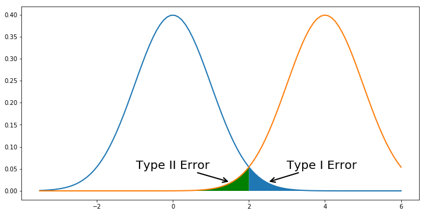

```python
# -*- coding: utf-8 -*-

import seaborn as sns
import pandas as pd
import scipy as sp
import matplotlib as mpl
import matplotlib.pylab as plt
import numpy as np
%matplotlib inline
from matplotlib.patches import Polygon


x = np.linspace(-3.5, 6, 100)
y1 = sp.stats.norm.pdf(x, loc=0)
y2 = sp.stats.norm.pdf(x, loc=4)

plt.figure(figsize=(12,6))
plt.plot(x, y1, linewidth=2)
plt.plot(x, y2, linewidth=2)

ix1 = np.linspace(2, 3.5, 100)
iy1 = sp.stats.norm.pdf(ix1, loc=0)
verts1 = [(2, 0)] + list(zip(ix1, iy1)) + [(3.5, 0)]
poly1 = Polygon(verts1)
plt.gca().add_patch(poly1)

# plt.annotate ← 글자와 화살표 추가
## xytext=(a, b) -> 글자 위치, xy=(a, b) -> 가리킬 포인트 위치
plt.annotate("Type I Error", xytext=(3, 0.05), xy=(2.5, 0.02), horizontalalignment='left', fontsize=20, arrowprops=dict(arrowstyle="->", linewidth=2))

ix2 = np.linspace(0, 2, 100)
iy2 = sp.stats.norm.pdf(ix2, loc=4)
verts2 = [(0, 0)] + list(zip(ix2, iy2)) + [(2, 0)]
poly2 = Polygon(verts2, facecolor='g')
plt.gca().add_patch(poly2)
plt.annotate("Type II Error", xytext=(0, 0.05), xy=(1.5, 0.02), horizontalalignment='center', fontsize=20, arrowprops=dict(arrowstyle="->", linewidth=2))
```

#### 유의확률(P-value)에 대한 예를 살펴 보자.

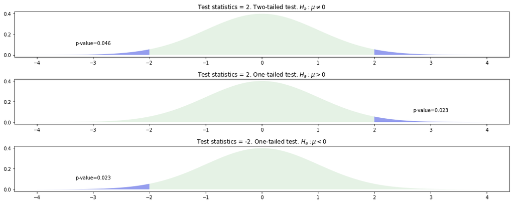

```python
xx1 = np.linspace(-4, 4, 100)
xx2 = np.linspace(-4, -2, 100)
xx3 = np.linspace(2, 4, 100)


plt.figure(figsize=(15,6))

plt.subplot(3, 1, 1)
plt.fill_between(xx1, sp.stats.norm.pdf(xx1), facecolor='green', alpha=0.1)
plt.fill_between(xx2, sp.stats.norm.pdf(xx2), facecolor='blue', alpha=0.35)
plt.fill_between(xx3, sp.stats.norm.pdf(xx3), facecolor='blue', alpha=0.35)
plt.text(-3, 0.1, "p-value=%5.3f" % (2*sp.stats.norm.cdf(-2)), horizontalalignment='center')
plt.title(r"Test statistics = 2. Two-tailed test. $H_a: \mu \neq 0$")

plt.subplot(3, 1, 2)
plt.fill_between(xx1, sp.stats.norm.pdf(xx1), facecolor='green', alpha=0.1)
plt.fill_between(xx3, sp.stats.norm.pdf(xx3), facecolor='blue', alpha=0.35)
plt.text(3, 0.1, "p-value=%5.3f" % (sp.stats.norm.cdf(-2)), horizontalalignment='center')
plt.title(r"Test statistics = 2. One-tailed test. $H_a: \mu > 0$")

plt.subplot(3, 1, 3)
plt.fill_between(xx1, sp.stats.norm.pdf(xx1), facecolor='green', alpha=0.1)
plt.fill_between(xx2, sp.stats.norm.pdf(xx2), facecolor='blue', alpha=0.35)
plt.text(-3, 0.1, "p-value=%5.3f" % (sp.stats.norm.cdf(-2)), horizontalalignment='center')
plt.title(r"Test statistics = -2. One-tailed test. $H_a: \mu < 0$")

plt.tight_layout()
plt.show()
```

#### 유의 확률(p-value)의 값이 작으므로 귀무가설은 기각된다.

### 유의 수준과 기각역

### 유의수준(level of significance)

> 계산된 유의 확률 값에 대해 귀무 가설을 기각하는지 채택하는지를 결정할 수 있는 기준 값

> 일반적으로 사용되는 유의 수준은 1%, 5%, 10% $$\alpha = 0.01,\;\; 0.05,\;\; 0.1$$

> **유의 수준과 유의 확률을 비교 후 판단**

### 기각역(critical value)

> 특정한 유의 확률 값에 대해 해당하는 검정 통계량

> **기각역과 검정 통계량을 비교 후 판단**
> - 기각역 값을 알고 있다면 검정 통계량을 비교하여 기각/채택 여부를 판단할 수 있다.

### 신뢰 수준(confidence level)

> 1 - alpha → 신뢰 수준

> alpha = 0.01 → 신뢰 수준 99%

> alpha = 0.05 → 신뢰 수준 95%

### 이제 가설과 검정 ① 서두에서 제기한 문제를 다시 풀어보자.

> 문제1
> - 어떤 동전을 15번 던졌더니 12번이 앞면이 나왔다. 이 동전은 휘어지지 않은 공정한 동전(fair coin, 앞 뒤 확률이 각 각 0.5)인가?

> 여기서 검정 통계량은 15번 던져 앞면이 나온 횟수가 12이고 이 값은 자유도가 15인 이항 분포를 따른다.

> 이 경우의 유의 확률(p-value) = 1.76% 이다.

$$ \text{Bin}(n \geq 12;N=15) = 0.017578125 $$

```python
# N = 15, n = 12, p = 0.5
## sp.stats.binom(N, P).cdf(n-1)
1 - sp.stats.binom(15, 0.5).cdf(12-1)
```

```
0.017578125
```

#### 이 값은 5% 보다는 작고 1% 보다는 크기 때문에 유의 수준이 5% 라면 귀무가설을 기각할 수 있으며(즉, 공정한 동전이 아니라고 말할 수 있다.)

> 단, 유의 수준이 0.01 이라면 기각할 수 없다.(즉, 공정한 동전이 아니라고 말할 수 없다.)
- 문제2

> 수익률이 정규 분포를 따른 다고 가정하면 이 트레이더의 검정통계량은 다음과 같이 계산된다.

$$ t = \dfrac{\bar{x}}{s\;/\sqrt{N}} = -1.4025 $$

> 이 검정 통계량에 대한 유의 확률은 11.67%이다.

$$ F(t=-1.4025;4) = 0.1167 $$

```python
x = np.array([-0.025, -0.05, 0.043, -0.037, -0.056])
t = x.mean()/x.std(ddof=1)*np.sqrt(len(x))
t, sp.stats.t(df=4).cdf(t)
```

```
(-1.4025921414082105, 0.11669216509589829)
```

> Share this on → [Tweet](https://twitter.com/share)

#### Related Posts

- [모수 추정 ③ (베이지안 모수 추정 MAP)](http://localhost:4000/statistics/2017/09/18/probability/) (Categories: statistics)
- [모수 추정 ② (MLE 계산)](http://localhost:4000/statistics/2017/09/17/probability/) (Categories: statistics)
- [모수 추정 ① (MM, MLE)](http://localhost:4000/statistics/2017/09/15/probability/) (Categories: statistics)
- [가설과 검정 ③](http://localhost:4000/statistics/2017/09/14/probability/) (Categories: statistics)
- [가설과 검정 ①](http://localhost:4000/statistics/2017/09/13/probability/) (Categories: statistics)
- [다변량 가우시안 정규분포](http://localhost:4000/probability/statistics/2017/09/11/probability_2/) (Categories: probability, statistics)

> « 가설과 검정 ① 가설과 검정 ③ »